# Project_1

**Importing the data of nearby cities**

```python
import numpy as np
import pandas as pd
df = pd.read_csv("C:\\Users\\nitis\\OneDrive\\Desktop\\4 Achievers Project\\My project Raw data\\01-01-2021.csv")
df.head(5)
```

|  | name | id | lat | lon | cumulative_revenue | design_capacity | fee_effective_date | rates | location | capital_cost | project_type | date_fee_notification | date_commercial_operation | fee_rule | concessions_period | traffic_per_day | target_traffic_per_day | contractor_name | contact_details |
| --- | --- | --- | --- | --- | --- | --- | --- | --- | --- | --- | --- | --- | --- | --- | --- | --- | --- | --- | --- |
| 0 | Thakurtola (End of Durg Bypass) | 4 | 21.117914 | 81.122298 | 30781.84 | NaN | 01-09-2019 | {"car_single":null,"car_multi":140,"car_monthl... | <b style='color:#22A7EA'>Thakurtola (End of Du... | 464.00 | BOT (Toll) | 20-12-2011 | 15-02-2012 | NaN | 1997 | 22246.0 | 22246.0 | M/s Ashoka Highways Durg Ltd | Mr Mukesh Devangan / 8889811172 |
| 1 | Bankapur | 5 | 14.909990 | 75.279800 | 263.30 | NaN | 25-02-2018 | {"car_single":null,"car_multi":80,"car_monthly... | <b style='color:#22A7EA'>Bankapur</b><br/><b> ... | 317.69 | Public Funded | 16-07-2012 | 03-03-2008 | 2008 as amended with transition | 03.01.2016-03.01.2017extended period | 25077.0 | NaN | Ms Sri Sai Enterprises | Shri Rajesh / 9901793636 |
| 2 | Hirebagewadi | 6 | 15.763110 | 74.647850 | 328.40 | NaN | 01-04-2020 | {"car_single":null,"car_multi":140,"car_monthl... | <b style='color:#22A7EA'>Hirebagewadi</b><br/>... | 996.60 | BOT (Toll) | 05-04-2011 | 07-07-2007 | 2008 | 04.05.2011-03.05.2041 | 27249.0 | NaN | M/s Ashoka Belgaum Dharwad Tollway Ltd | Mr T. George / 8970999401 |
| 3 | Durg Bypass (Dhamdanaka) | 7 | 21.214518 | 81.287962 | 404.89 | 15000.0 | 01-04-2019 | {"car_single":null,"car_multi":null,"car_month... | <b style='color:#22A7EA'>Durg Bypass (Dhamdana... | 123.00 | BOT (Toll) | 13-12-2001 | 15-12-2000 | 1997 | 01.04.2011-29.03.2031 | 20742.0 | 20742.0 | Ms Durg Shivnath Expressways Pvt Ltd. | Sh Hemant Kumar / 9009990182 |
| 4 | Hattargi | 8 | 16.143300 | 74.516960 | 164.50 | NaN | 01-04-2020 | {"car_single":null,"car_multi":45,"car_monthly... | <b style='color:#22A7EA'>Hattargi</b><br/><b> ... | 559.49 | Public Funded | 26-10-2012 | 28-04-2007 | 2008 as amended with transition | 16.01.2016-16.01.2017extended period | 33898.0 | NaN | Sh. V. Vidyasagar Reddy | Syed Abdul Rahman / 8618001170 |

```python
col_list = ["name","cumulative_revenue","project_type","traffic_per_day"]
df1 = df[col_list]

df1 = df1.head(20)
df1.loc[df1.cumulative_revenue == 30781.84,'cumulative_revenue'] = 265 #updating the col vals
df1.loc[df1.cumulative_revenue == 100000,'cumulative_revenue'] = 290

df1                # all the nearby cities to our Highway
```

|  | name | cumulative_revenue | project_type | traffic_per_day |
| --- | --- | --- | --- | --- |
| 0 | Thakurtola (End of Durg Bypass) | 265.00 | BOT (Toll) | 22246.0 |
| 1 | Bankapur | 263.30 | Public Funded | 25077.0 |
| 2 | Hirebagewadi | 328.40 | BOT (Toll) | 27249.0 |
| 3 | Durg Bypass (Dhamdanaka) | 404.89 | BOT (Toll) | 20742.0 |
| 4 | Hattargi | 164.50 | Public Funded | 33898.0 |
| 5 | Kognoli | 282.87 | Public Funded | 44415.0 |
| 6 | Tundla | 290.00 | BOT (Toll) | 47978.0 |
| 7 | Brahamarakotlu | 25.57 | Public Funded | 33886.0 |
| 8 | Cable Stayed Naini Bridge | 112.23 | Public Funded | 52993.0 |
| 9 | Bassi | 148.05 | OMT | 10168.0 |
| 10 | Aroli | 148.05 | OMT | 9900.0 |
| 11 | Dhaneshwar | 148.05 | OMT | 11617.0 |
| 12 | Fatehpur | 63.75 | OMT | 9515.0 |
| 13 | Simliya | 63.75 | OMT | 12970.0 |
| 14 | Omallur | 439.67 | BOT (Toll) | 54304.0 |
| 15 | Nathakkarai | 302.08 | BOT (Toll) | 25484.0 |
| 16 | Veeracholapuram (West) | 302.08 | BOT (Toll) | 36196.0 |
| 17 | Palayam (Dharmapuri) | 944.56 | BOT (Toll) | 55726.0 |
| 18 | Rasampalayan | 190.26 | BOT (Toll) | 23232.0 |
| 19 | Nemili (Sriperumbudur) | 227.99 | Public Funded | 91814.0 |

#### 1) Using Python, how would you analyze the traffic flow data for nearby cities to predict the vehicle distribution on the new highway?

#### Answer:-

```python
#taken data of 20 nearby cities to our new highway and usning that data taken out mean traffic at per Toll at the 20 cities.
Daily_traffic = df1[["traffic_per_day"]].mean(axis=0)
Daily_traffic
```

```
traffic_per_day    32470.5
dtype: float64
```

So, if we consider the average value of dialy traffic passing through the nearby cities of our New Highway then the average comes out to be 32471 vehicles per day through one toll plaza

#### 2) With the given toll locations, how would you create a graph in Python to represent the expected vehicle flow at each toll booth over a 24-hour period?

#### Answer:-

importing the data of all 4 Toll Plazas

```python
import pandas as pd
import numpy as np
import matplotlib.pyplot as plt

df = pd.read_excel("C:\\Users\\nitis\\Downloads\\My project data1 (3).xlsx")  #reading the file
# taking only required columns
df1 = df[["date","day","Total vehicles at (T1)","Total vehicles at (T2)","Total vehicles at (T3)","Total vehicles at (T4)"]]
df1 = df1.head(7)
df1
```

|  | date | day | Total vehicles at (T1) | Total vehicles at (T2) | Total vehicles at (T3) | Total vehicles at (T4) |
| --- | --- | --- | --- | --- | --- | --- |
| 0 | 2023-01-01 | Sunday | 5755 | 9562 | 6521 | 8602 |
| 1 | 2023-01-02 | Monday | 5762 | 9604 | 8820 | 7123 |
| 2 | 2023-01-03 | Tuesday | 6493 | 9420 | 8261 | 8380 |
| 3 | 2023-01-04 | Wednesday | 6490 | 7915 | 7795 | 9327 |
| 4 | 2023-01-05 | Thursday | 6509 | 6719 | 9402 | 7943 |
| 5 | 2023-01-06 | Friday | 6383 | 7146 | 9736 | 9138 |
| 6 | 2023-01-07 | Saturday | 6499 | 7587 | 8507 | 9423 |

plot of 24 hours vehicle flow data (of a Week):-

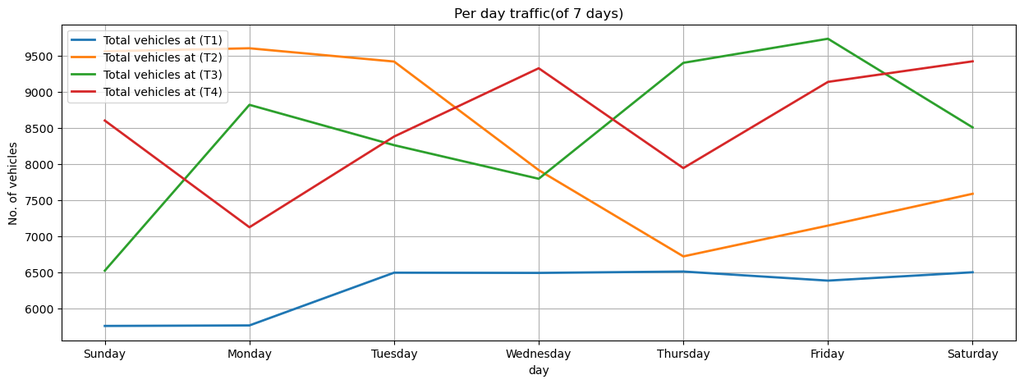

```python
df1.plot(x='day',y=["Total vehicles at (T1)","Total vehicles at (T2)","Total vehicles at (T3)","Total vehicles at (T4)"],linewidth=2,figsize=(15,5))
plt.ylabel("No. of vehicles")
plt.xlabel("day")
plt.title("Per day traffic(of 7 days)")
plt.grid()
```

plot of 24 hours vehicle flow data (Only Sunday):-

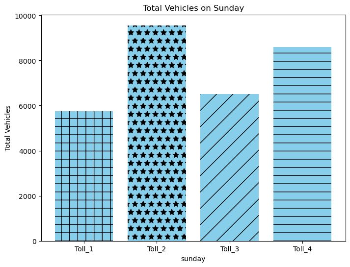

```python
# Data
Tolls = ["Toll_1", "Toll_2", "Toll_3", "Toll_4"]
total_vehicles = [5755, 9562, 6521, 8602]

# Create a bar plot

plt.figure(figsize=(8, 6))
bars = plt.bar(Tolls, total_vehicles, color='skyblue')
plt.xlabel("sunday")
plt.ylabel("Total Vehicles")
plt.title(f"Total Vehicles on Sunday")
patterns=['+','*','/','-']
for i in bars:
    i.set_hatch(patterns.pop(0))
plt.show()
```

### Additional questions:-

###### a) How would you assess the impact of seasonal variations, such as monsoons or festivals, on the traffic flow and toll revenues using Python?

##### Answer:-

```python
import numpy as np
import pandas as pd
df = pd.read_excel("C:\\Users\\nitis\\Downloads\\seasons and fest.xlsx")
df.head(5)
```

|  | id | date | season | festival | Total_vehicles(all Tolls) | Total_Tax(all tolls) | payment_mode |
| --- | --- | --- | --- | --- | --- | --- | --- |
| 0 | 1 | 2023-01-01 | winter | NaN | 30302 | 2532947 | cash |
| 1 | 2 | 2023-01-02 | winter | NaN | 31961 | 2596725 | cash |
| 2 | 3 | 2023-01-03 | winter | NaN | 32073 | 2028032 | Fastag |
| 3 | 4 | 2023-01-04 | winter | NaN | 32191 | 2145858 | Fastag |
| 4 | 5 | 2023-01-05 | winter | NaN | 30464 | 2042992 | cash |

###### ----------------------------------------------Impact of seasons on traffic flow and toll revenues----------------

```python
seasons = df.groupby('season').sum().sort_values(by='Total_vehicles(all Tolls)', ascending=True)
#seasons
# Calculating Percentage of data cols=[Total_vehicles(all Tolls), Total_Tax(all tolls)]

seasons['Vehicle_percent'] = (seasons['Total_vehicles(all Tolls)'] /
                  seasons['Total_vehicles(all Tolls)'].sum()) * 100
seasons['Tax_percent'] = (seasons['Total_Tax(all tolls)'] /
                  seasons['Total_Tax(all tolls)'].sum()) * 100
seasons
```

| season | id | Total_vehicles(all Tolls) | Total_Tax(all tolls) | Vehicle_percent | Tax_percent |
| --- | --- | --- | --- | --- | --- |
| autumn | 18544 | 2616579 | 160805734 | 18.652016 | 17.130360 |
| summer | 12376 | 3537203 | 233640264 | 25.214590 | 24.889298 |
| monsoon | 20930 | 3721991 | 232864452 | 26.531832 | 24.806652 |
| winter | 14945 | 4152625 | 311407315 | 29.601562 | 33.173689 |

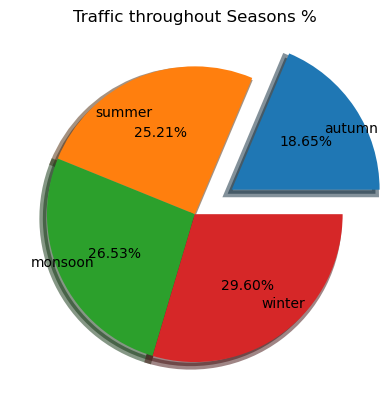

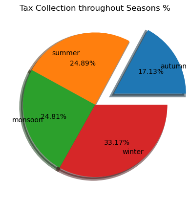

```python
#____________________________________________Traffic throughout Seasons__________________________________________________________

x = ['autumn', 'summer', 'monsoon', 'winter']
y= seasons['Vehicle_percent']
ex=[0.3,0,0,0]
#rotatelabels=True(rotates the labels) it should be written in wedgeprops
plt.pie(y,labels=x,explode=ex, autopct="%0.2f%%",shadow=True, radius=1, labeldistance=.75,textprops={"fontsize":10},
       wedgeprops={'linewidth':5})
plt.title("Traffic throughout Seasons %")
plt.show()

#____________________________________________Tax Collection throughout Seasons____________________________________________________


x = ['autumn', 'summer', 'monsoon', 'winter']
y= seasons['Tax_percent']
ex=[0.3,0,0,0]
#rotatelabels=True(rotates the labels) it should be written in wedgeprops
plt.pie(y,labels=x,explode=ex, autopct="%0.2f%%",shadow=True, radius=1, labeldistance=.75,textprops={"fontsize":10},
       wedgeprops={'linewidth':5})
plt.title("Tax Collection throughout Seasons %")
plt.show()
```

###### ----------------------------------------------Impact of "Festivals" on traffic flow and toll revenues----------------

```python
df.dropna(subset = ['festival'])
```

|  | id | date | season | festival | Total_vehicles(all Tolls) | Total_Tax(all tolls) | payment_mode |
| --- | --- | --- | --- | --- | --- | --- | --- |
| 48 | 49 | 2023-02-18 | winter | Mahashivratri | 61388 | 3537796 | cash |
| 66 | 67 | 2023-03-08 | winter | Holi | 50832 | 4587126 | Fastag |
| 88 | 89 | 2023-03-30 | winter | Ram Navmi | 45225 | 3998554 | Fastag |
| 96 | 97 | 2023-04-07 | summer | Good Friday | 42673 | 3858407 | cash |
| 111 | 112 | 2023-04-22 | summer | Ramzan | 49887 | 4174081 | Fastag |
| 179 | 180 | 2023-06-29 | summer | Bakrid | 51666 | 4910336 | cash |
| 226 | 227 | 2023-08-15 | monsoon | Independence day | 54342 | 4712984 | cash |
| 248 | 249 | 2023-09-06 | monsoon | Janmashtmi | 54317 | 4979452 | Fastag |
| 274 | 275 | 2023-10-02 | autumn | Gandhi Jayanti | 51405 | 4813792 | Fastag |
| 296 | 297 | 2023-10-24 | autumn | Dussehra | 50554 | 4736853 | cash |
| 315 | 316 | 2023-11-12 | autumn | Diwali | 60122 | 5244451 | Fastag |
| 358 | 359 | 2023-12-25 | winter | Christmas | 50334 | 4937424 | Fastag |

**Observation:-** Here we can see that the "Total number of Vehicles" increases on the "Festive days" so does the " Tax collection"

#### b) What measures would you propose to ensure an equitable toll pricing strategy that considers the varying socioeconomic backgrounds of highway users?

###### Answer:-

**To ensure an equitable toll pricing strategy that considers varying socioeconomic backgrounds:-**

1. **Income-Based Discounts:** Provide discounts or exemptions for lower-income users.
2. **Variable Pricing:** Adjust toll rates based on factors like time of day and traffic conditions.
3. **Carpool and HOV Incentives:** Encourage carpooling with reduced or waived tolls.
4. **Transit Subsidies:** Invest in public transportation and offer subsidies to reduce reliance on tolls.
5. **Toll Credit Programs:** Offer credits or refunds for low-income frequent users.
6. **Data-Driven Decisions:** Use data to assess the impact on different socioeconomic groups.
7. **Public Engagement:** Involve the public in decision-making and gather feedback.
8. **Equity Impact Assessments:** Evaluate toll changes' effects on different communities.
9. **Partnerships:** Collaborate with governments and organizations to develop equitable strategies.
10. **Education and Outreach:** Inform users about tolling options and alternatives.
11. **Regular Review:** Continuously assess and adjust toll strategies for equity.
12. **Legislation and Policy:** Advocate for equitable policies in transportation planning.

By considering these measures, tolling systems can become fairer and more inclusive.

#### c) How might you utilize Python to conduct a cost analysis of the toll collection process, taking into account operational expenses and maintenance costs for each toll booth?

#### Answer:-

**To conduct a cost analysis of toll collection, including operational expenses and maintenance costs for each toll booth, Python can be used for:**

1. **Data Collection:** Gather cost data for each toll booth.
2. **Data Analysis:** Analyze and calculate total operational and maintenance costs using Python's Pandas library.
3. **Visualization:** Create visual reports and charts with Python's Matplotlib and Seaborn libraries.
4. **Cost Allocation:** Allocate costs to specific toll booths for clarity.
5. **Cost Forecasting:** Predict future expenses using Python's modeling capabilities.
6. **Scenario Analysis:** Analyze cost impacts by adjusting variables.
7. **Automation:** Automate data retrieval and analysis for regular updates.
8. **Integration:** Integrate Python with other systems and data sources for streamlined analysis.

*Python's versatility makes it a valuable tool for comprehensive cost analysis and data-driven decision-making. By using Python for these steps, you can conduct a comprehensive cost analysis of toll collection operations, enabling you to make informed decisions regarding toll booth management, cost optimization, and budget planning. Python's flexibility and extensive libraries make it a powerful tool for data analysis and cost modeling.

```python
ca = pd.read_excel("C:\\Users\\nitis\\Downloads\\Cost Analysis1 (1).xlsx")
ca["revenue_2022"] = [2500000,2200000,1900000,1700000]  #adding revenue column for 2022
ca["revenue_2023"] = [3000000,2700000,2300000,2100000]  #adding revenue column for 2023
ca["%change(2022 to 2023)"] = ca["%change(2022 to 2023)"]*100  #for taking percentage as in raw data it was not mulyipplied by 100
ca1 = ca.sort_values(["Year_2022(total cost/day)"])
ca1
```

|  | Date | TollBoothID | Location | Operational Expenses(2023) | Maintanance Cost(2023) | Miscellaneous Costs(2023) | Year_2022(total cost/day) | Year_2023(total cost/day) | %change(2022 to 2023) | revenue_2022 | revenue_2023 |
| --- | --- | --- | --- | --- | --- | --- | --- | --- | --- | --- | --- |
| 3 | 2023-01-04 | T4 | city_4 | 750 | 390 | 870 | 2020 | 2010 | -0.495050 | 1700000 | 2100000 |
| 2 | 2023-01-03 | T3 | city_3 | 800 | 400 | 900 | 2300 | 2100 | -8.695652 | 1900000 | 2300000 |
| 1 | 2023-01-02 | T2 | city_2 | 900 | 410 | 1000 | 2700 | 2310 | -14.444444 | 2200000 | 2700000 |
| 0 | 2023-01-01 | T1 | city_1 | 1200 | 450 | 1100 | 3200 | 2750 | -14.062500 | 2500000 | 3000000 |

**Visual representation:-**

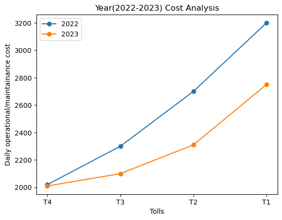

```python
import matplotlib.pyplot as plt

# Define the x-axis values and the corresponding tea and coffee values
x_ticks = ['T4', 'T3', 'T2', 'T1']
y_ticks = [2000, 2500, 3000, 3500]

y1 = ca1["Year_2022(total cost/day)"]
y2 = ca1["Year_2023(total cost/day)"]

# Create a figure and axis
fig, ax = plt.subplots()

# Plot the tea data
ax.plot(x_ticks, y1, marker='o', label='2022')

# Plot the coffee data
ax.plot(x_ticks, y2, marker='o', label='2023')

# Add labels and a legend
ax.set_xlabel('Tolls')
ax.set_ylabel('Daily operational/maintainance cost')
ax.set_title('Year(2022-2023) Cost Analysis')
ax.legend()

# Show the plot
plt.show()
```

**Assuming we are operation from year 2022:-** As we can see that the percentage change in the expenses has deacreased in year 2023 when compared with year 2022, it shows that we are getting more cost effective and we can allocate lesser money for expenses compared to 2022.

also the numer of vehicles have increased in year 2023 resulting in more revenue genration in financial year 2023.

**Conclusion:-** we have our oprational and maintance costs reduced and our Revenue have increased, so we are operating much nicely as compared to year 2022(which is a good sign of progress)

#### d) What steps would you recommend for implementing a dynamic pricing model that adjusts toll rates based on real-time traffic conditions and demand fluctuations?

### Answer:-

**Implementing a dynamic pricing model for toll rates that adjusts based on real-time traffic conditions and demand fluctuations can help optimize traffic flow and revenue. Here are some steps we can consider for implementing such a model:**

1. **Data Collection and Analysis**:
   - Gather real-time traffic data.
   - Analyze traffic patterns and demand.
2. **Algorithm Development**:
   - Create pricing algorithms that consider factors like traffic volume and congestion levels..
3. **Pricing Rules and Policies**:
   - Define rules and policies for adjusting toll rates based on real-time data.
   - Set rate caps to prevent excessive pricing during peak hours.
4. **Communication**:
   - Communicate pricing changes through digital signs, apps, and websites
5. **Testing and Feedback**:
   - Conduct simulations to evaluate pricing model impact on traffic and revenue and refine the model.
6. **Regulation and Privacy**:
   - Ensure legal compliance and data security.
7. **Continuous Monitoring**:
   - Implement real-time control and Include mechanisms for manual rate adjustments when needed.

Implementing dynamic toll pricing involves data analysis, algorithm development, pricing rules, communication, testing, legal compliance, and continuous monitoring.

#### e) How could you analyze the environmental impact of the new highway and integrate eco-friendly toll policies using Python's data analysis capabilities?

### Answer:-

**Analyzing the environmental impact of a new highway and integrating eco-friendly toll policies using Python's data analysis capabilities can be achieved through various steps:**

1. **Data Collection**:
   - Gather data on highway traffic, vehicle types, emissions, and geographical features.
2. **Analysis**:
   - Using Python libraries like Pandas and NumPy for data analysis.
   - Performing geospatial analysis to assess the highway's impact on the environment.
3. **Emissions Assessment**:
   - By Calculating emissions produced by highway traffic.
4. **Environmental Impact**:
   - By Evaluating air quality, noise, and habitat disruption.
5. **Eco-Friendly Toll Policies**:
   - By Developing toll policies encouraging eco-friendly transportation methods, like carpooling and electric vehicles.
6. **Data Visualization**:
   - Then Visualizing results using Python's Matplotlib and Seaborn.
7. **Recommendations**:
   - By implementing eco-friendly toll policies based on the analysis to reduce environmental impact.
8. **Monitoring and Adaptation**:
   - Continuously monitoring and adjusting toll policies for ongoing environmental improvement.

Python's data analysis capabilities, combined with environmental and geographical data, allow for a comprehensive assessment of the highway's impact on environment. By integrating eco-friendly toll policies, we can contribute to minimizing the environmental footprint of the transportation infrastructure.

#### f) What strategies could be employed to ensure transparency and accountability in toll collection procedures, minimizing the potential for revenue mismanagement or discrepancies?

#### Answer:-

**To ensure transparency and accountability in toll collection procedures and minimize the potential for revenue mismanagement or discrepancies, the following strategies can be employed:-**

1. **Automated Toll Collection**:
   - Implement electronic toll collection systems to reduce manual errors.
2. **Real-Time Data Tracking**:
   - Use technology for real-time monitoring of toll transactions.
3. **Auditing and Oversight**:
   - Conduct regular independent audits of toll collection processes and financial records.
4. **Financial Transparency**:
   - Make financial records and toll collection data accessible to the public and relevant authorities.
5. **Contractual Accountability**:
   - Ensure clear contract terms, performance metrics, and penalties for non-compliance with toll operators.
6. **Legal Compliance**:
   - Ensure compliance with local and national laws and regulations.

These strategies will help minimize revenue mismanagement and discrepancies while maintaining transparency and accountability in toll collection.

#### g) How would you leverage Python's statistical tools to identify any correlations between toll prices, vehicle types, and the frequency of highway usage, aiding in the development of targeted pricing structures?

#### Answer:-

**To leverage Python's statistical tools to identify correlations between toll prices, vehicle types, and the frequency of highway usage for developing targeted pricing structures, we can follow these steps:-**

1. **Data Collection and Preparation**:
   - Gather data on toll prices, vehicle types, and usage frequency.
   - Clean and preprocess the data, ensuring it's in a structured format.
2. **Data Exploration**:
   - Use Python libraries like Pandas to explore the data, calculate summary statistics, and visualize distributions.
3. **Correlation Analysis**:
   - Utilize Python's statistical tools, such as NumPy and Pandas, to calculate correlation coefficients, such as Pearson correlation, between toll prices, vehicle types, and usage frequency.
4. **Statistical Tests**:
   - Conduct statistical tests, such as ANOVA or t-tests, to determine if there are significant differences in usage frequency based on vehicle types or toll prices.
5. **Visualization**:
   - Create visualizations, such as scatter plots, heatmaps, and bar charts, to visualize correlations and differences between variables.
1. **Segmentation**:
   - Segment the data into groups based on the identified correlations and patterns. For example, create groups of vehicle types with similar usage behavior.

By leveraging Python's statistical and data analysis capabilities, you can gain insights into the relationships between toll prices, vehicle types, and highway usage. This information is essential for developing targeted pricing structures that encourage desired behaviors and optimize revenue while improving the efficiency of the highway system.

```python
#importing data
import numpy as np
import pandas as pd
df = pd.read_excel("C:\\Users\\nitis\\OneDrive\\Desktop\\4 Achievers Project\\My project Raw data\\g) corelation data.xlsx")
df1= df.head(6)
df1
```

|  | id | date | day | vehicle_type(car)_T1 | vehicle_type(LCV)_T1 | vehicle_type(Bus/Truck)_T1 | Total vehicles at (T1) | Total vehicles at (T2) | Total vehicles at (T3) | Total vehicles at (T4) | collection_toll1 | collection_toll2 | collection_toll3 | collection_toll4 | payment_mode | total_tax_amt |
| --- | --- | --- | --- | --- | --- | --- | --- | --- | --- | --- | --- | --- | --- | --- | --- | --- |
| 0 | 1 | 2023-01-01 | Sunday | 4258 | 941 | 556 | 5755 | 9562 | 6521 | 8602 | 561860 | 747762 | 553151 | 695699 | cash | 1883667 |
| 1 | 2 | 2023-01-02 | Monday | 4134 | 1103 | 525 | 5762 | 9604 | 8820 | 7123 | 562630 | 888598 | 620142 | 768083 | cash | 1853517 |
| 2 | 3 | 2023-01-03 | Tuesday | 4456 | 1091 | 946 | 6493 | 9420 | 8261 | 8380 | 690710 | 898142 | 807634 | 685777 | Fastag | 1949247 |
| 3 | 4 | 2023-01-04 | Wednesday | 4605 | 958 | 927 | 6490 | 7915 | 7795 | 9327 | 682505 | 607234 | 870852 | 661702 | Fastag | 1862998 |
| 4 | 5 | 2023-01-05 | Thursday | 4530 | 1156 | 823 | 6509 | 6719 | 9402 | 7943 | 672660 | 877777 | 821187 | 837538 | cash | 1931568 |
| 5 | 6 | 2023-01-06 | Friday | 4442 | 1287 | 654 | 6383 | 7146 | 9736 | 9138 | 638220 | 539481 | 785333 | 853763 | Fastag | 1851155 |

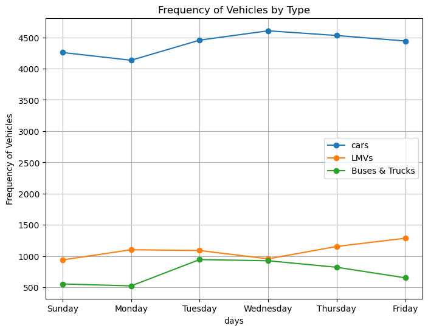

```python
import matplotlib.pyplot as plt


days = df1["day"]
freq_car = df1["vehicle_type(car)_T1"]
freq_LMV = df1["vehicle_type(LCV)_T1"]
freq_Bus_Truck = df1["vehicle_type(Bus/Truck)_T1"]

# Creating the line chart
plt.figure(figsize=(8, 6))
plt.plot(days, freq_car, marker='o', label='cars')
plt.plot(days, freq_LMV, marker='o', label='LMVs')
plt.plot(days, freq_Bus_Truck, marker='o', label='Buses & Trucks')

# Customizing the chart
plt.title('Frequency of Vehicles by Type')
plt.xlabel('days')
plt.ylabel('Frequency of Vehicles')
plt.legend()
plt.grid(True)

# Show the chart
plt.show()
```

**---> So this way we can use pandas and matplotlib to analyze the corelations between "Frequency of vehicles at Tolls" at any particular day and get to know that which vehicle type is the highest and lowest in number at any particular day passing through any of our tolls. The above illusstration was made for "Toll_1" we can repeta the same method for other tolls and gather important insights.**

**Conclusion:-** Here we conclude that at **"Toll_1"** the type of vehicle that is most frequent is **"cars"** and **"Bus/ Truck"** the the least frequent.

#### h) What innovative data visualization techniques in Python could be employed to present the toll pricing strategies and their projected impact on the highway's usage and revenue generation?

#### Answer:-

**In Python, we can employ innovative data visualization techniques to present toll pricing strategies and their projected impact on highway usage and revenue:-**

1. **Heatmaps**: Visualize traffic congestion and revenue changes under different toll strategies.
2. **Sankey Diagrams**: Illustrate the flow of vehicles and revenue distribution.
3. **Interactive Dashboards**: Create user-friendly tools for exploring toll scenarios.
4. **Choropleth Maps**: Show regional variations in usage and revenue.
5. **Tree Maps**: Display the allocation of revenue to different areas.
6. **Streamgraphs**: Visualize changes in revenue over time.
7. **Parallel Coordinates**: Demonstrate relationships between toll policies and impact.
8. **Word Clouds**: Highlight key concepts and keywords.
9. **Network Graphs**: Illustrate interconnections between factors.
10. **Small Multiple Plots**: Display variations in revenue and traffic in a compact format.

These techniques can help convey toll pricing strategies and their impact on the highway effectively.

**For example:-(using dummy data)**

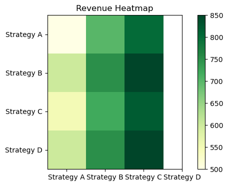

```
_________________________________________________________________________________________________________________________
```

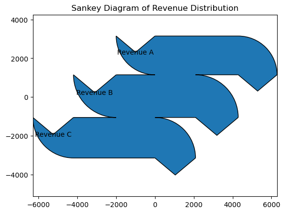

```
_________________________________________________________________________________________________________________________
```

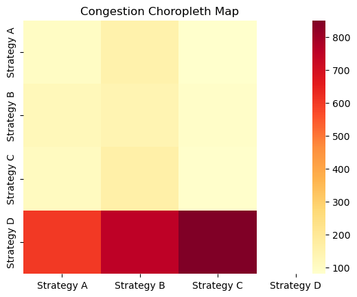

```
_________________________________________________________________________________________________________________________
_________________________________________________________________________________________________________________________
```

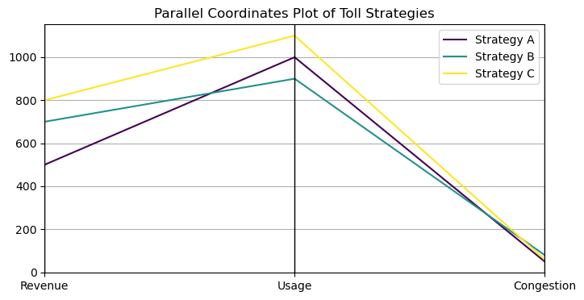

```
_________________________________________________________________________________________________________________________
```

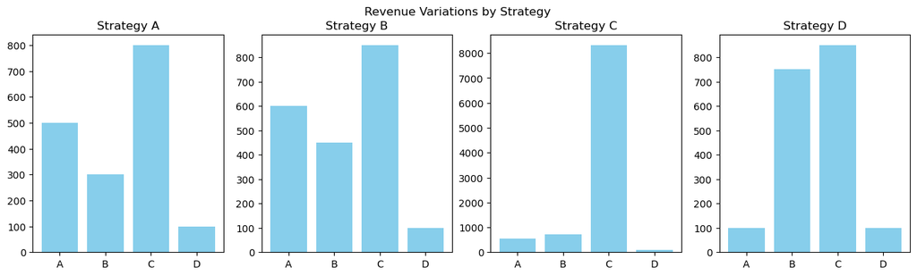

```python
import matplotlib.pyplot as plt
import numpy as np

# dummy data
toll_strategies = ['Strategy A', 'Strategy B', 'Strategy C','Strategy D']
revenue = np.array([[500, 700, 800], [600, 750, 850], [550, 720, 820], [600, 750, 850]])
congestion = np.array([[100, 150, 80], [120, 140, 90], [110, 160, 85], [600, 750, 850]])

# 1. Heatmap
plt.figure(figsize=(8, 4))
plt.imshow(revenue, cmap='YlGn', interpolation='nearest')
plt.colorbar()
plt.xticks(np.arange(len(toll_strategies)), toll_strategies)
plt.yticks(np.arange(len(toll_strategies)), toll_strategies)
plt.title('Revenue Heatmap')
plt.show()
print("_________________________________________________________________________________________________________________________")

# 2. Sankey Diagram
from matplotlib.sankey import Sankey

fig, ax = plt.subplots()
sankey = Sankey(ax=ax, unit=None)
sankey.add(flows=[-sum(revenue[0]), -sum(revenue[1]), -sum(revenue[2]), sum(revenue[0]), sum(revenue[1]), sum(revenue[2])],
           labels=['', '', '', 'Revenue A', 'Revenue B', 'Revenue C'],
           orientations=[-1, -1, -1, 1, 1, 1],
           pathlengths=[0.25, 0.25, 0.25, 0.25, 0.25, 0.25],
           trunklength=1)
diagrams = sankey.finish()
plt.title('Sankey Diagram of Revenue Distribution')
plt.show()

print("_________________________________________________________________________________________________________________________")

# 4. Choropleth Map
import seaborn as sns

sns.heatmap(congestion, xticklabels=toll_strategies, yticklabels=toll_strategies, cmap='YlOrRd')
plt.title('Congestion Choropleth Map')
plt.show()

print("_________________________________________________________________________________________________________________________")

# 7. Parallel Coordinates -
import pandas as pd
import matplotlib.pyplot as plt

# Creating a DataFrame
data = {    'Toll Strategy': ['Strategy A', 'Strategy B', 'Strategy C'],
    'Revenue': [500, 700, 800],
    'Usage': [1000, 900, 1100],
    'Congestion': [50, 80, 60]}
df = pd.DataFrame(data)

print("_________________________________________________________________________________________________________________________")

# Creating the parallel coordinates plot
plt.figure(figsize=(8, 4))
pd.plotting.parallel_coordinates(df, 'Toll Strategy', colormap='viridis')
plt.title('Parallel Coordinates Plot of Toll Strategies')
plt.legend(loc='upper right')
plt.show()

print("_________________________________________________________________________________________________________________________")




# 10. Small Multiple Plots
fig, axes = plt.subplots(1, 4, figsize=(16, 4))

toll_strategies = ['A', 'B', 'C', 'D']
revenue = np.array([[500, 300, 800, 100], [600, 450, 850, 100], [550, 720, 8320, 100], [100, 750, 850, 100]])

for i in range(4):
    axes[i].bar(toll_strategies, revenue[i], color='skyblue')
    axes[i].set_title(f'Strategy {toll_strategies[i]}')
plt.suptitle('Revenue Variations by Strategy')
plt.show()
```